# peer assessment 1

This assignment makes use of data from a personal activity monitoring device. This device collects data at 5 minute intervals through out the day. The data consists of two months of data from an anonymous individual collected during the months of October and November, 2012 and include the number of steps taken in 5 minute intervals each day. The variables included in this dataset are:

steps: Number of steps taking in a 5-minute interval (missing values are coded as NA)

date: The date on which the measurement was taken in YYYY-MM-DD format

interval: Identifier for the 5-minute interval in which measurement was taken

### Loading and preprocessing the data

We load the data and check variable formatting, dimensions, and the first six rows with the following code:

```r
activity=read.csv("activity.csv", stringsAsFactors=F)
str(activity)  ## check variable formats
```

```
## 'data.frame':    17568 obs. of  3 variables:
##  $ steps   : int  NA NA NA NA NA NA NA NA NA NA ...
##  $ date    : chr  "10/1/2012" "10/1/2012" "10/1/2012" "10/1/2012" ...
##  $ interval: int  0 5 10 15 20 25 30 35 40 45 ...
```

```r
dim(activity)  ## check dimensions
```

```
## [1] 17568     3
```

```r
head(activity) ## Look at first 6 rows
```

```
##   steps      date interval
## 1    NA 10/1/2012        0
## 2    NA 10/1/2012        5
## 3    NA 10/1/2012       10
## 4    NA 10/1/2012       15
## 5    NA 10/1/2012       20
## 6    NA 10/1/2012       25
```

Let’s look at summary statistics:

```r
summary(activity)
```

```
##      steps           date              interval
##  Min.   :  0.0   Length:17568       Min.   :   0
##  1st Qu.:  0.0   Class :character   1st Qu.: 589
##  Median :  0.0   Mode  :character   Median :1178
##  Mean   : 37.4                      Mean   :1178
##  3rd Qu.: 12.0                      3rd Qu.:1766
##  Max.   :806.0                      Max.   :2355
##  NA's   :2304
```

The largest interval is 2355, which is meant to be 23:55. I realized with some effort (not just the above line of code) that interval is coded as HHMM rather than just in minutes. I will recode it into minutes so that there won’t be gaps. I recode as follows

```r
interval.minutes = activity$interval %% 100
table(interval.minutes)
```

```
## interval.minutes
##    0    5   10   15   20   25   30   35   40   45   50   55
## 1464 1464 1464 1464 1464 1464 1464 1464 1464 1464 1464 1464
```

```r
interval.hour = activity$interval %/% 100
table(interval.hour)
```

```
## interval.hour
##   0   1   2   3   4   5   6   7   8   9  10  11  12  13  14  15  16  17
## 732 732 732 732 732 732 732 732 732 732 732 732 732 732 732 732 732 732
##  18  19  20  21  22  23
## 732 732 732 732 732 732
```

```r
activity$interval = interval.minutes + 60*interval.hour
summary(activity$interval)
```

[output not shown]

```r
60*24-1
```

```
## [1] 1439
```

We will also format the dates:

```r
activity$date =
  as.POSIXct(  as.character(activity$date), format="%m/%d/%y")
str(activity)
```

```
## 'data.frame':    17568 obs. of  3 variables:
##  $ steps   : int  NA NA NA NA NA NA NA NA NA NA ...
##  $ date    : POSIXct, format: "2020-10-01" "2020-10-01" ...
##  $ interval: num  0 5 10 15 20 25 30 35 40 45 ...
```

### What is mean total number of steps taken per day?

The next task is to make a histogram of total number of steps taken per day, and compute the mean and median total number of steps per day. To compute the total number of steps per day, we type:

```r
total.steps = tapply(activity$steps, activity$date, sum)
```

In this calculation, if number of steps was missing for one interval during a certain day, then the total will be missing for that day.

We create the histogram with the following code:

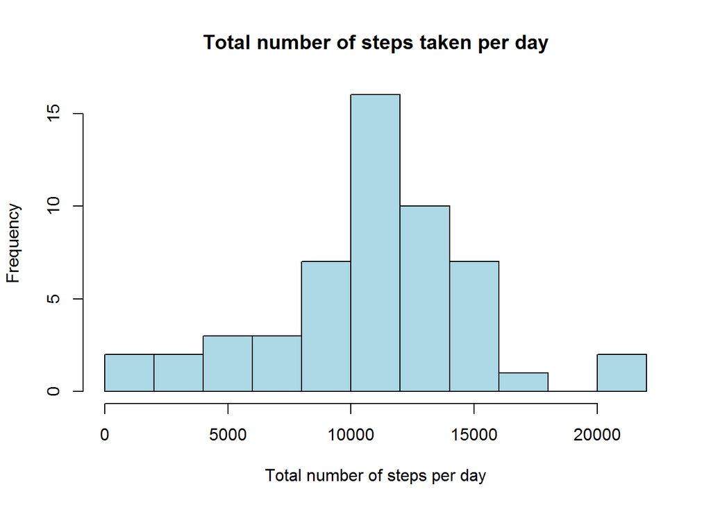

```r
hist(total.steps, main="Total number of steps taken per day",
     col="lightblue",
     breaks=12,
     xlab="Total number of steps per day")
```

We compute the mean and median, ignoring missing values, as follows:

```r
mean(total.steps, na.rm=T)
```

```
## [1] 10766
```

```r
median(total.steps, na.rm=T)
```

```
## [1] 10765
```